# k-NN regression

Introduction to statistical Learning

Pedro Delicado and Alex Sánchez

# Introduction

The $k$ nearest-neighbor estimator of $m(t)=E(Y|X=t)$ is defined as
$$\hat{m}(t) = \frac{1}{k} \sum_{i\in N_k(t)} y_i,$$
where $N_k(t)$ is the neighborhood of $t$ defined by the $k$ closest points $x_i$ in the training sample.

## Data for prediction

The Boston housing data, included in the `MASS` package, contains information on housing in the Boston suburbs area.

```r
library(MASS)
# help(Boston)
data(Boston)
```

## Main predicion goal

Our goal is to predict the housing mean value, stored in the `mdev` variable, using as predictor variable the percentage of population with lower socio-economic status. `lstat`.

## Data description

We start by plotting the values to show the relation among them.

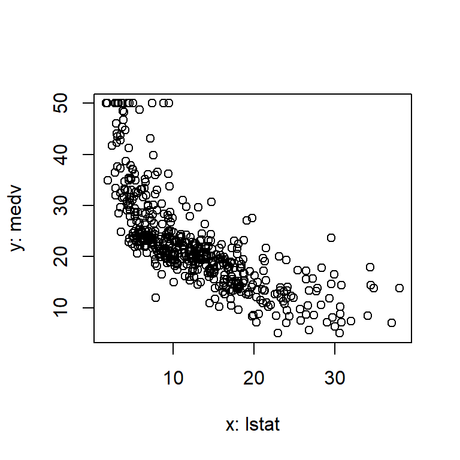

```r
x <- Boston$lstat
y <- Boston$medv
plot(x,y, xlab="x: lstat", ylab="y: medv")
```

We migt consider fitting a polynomial curve but we start with KNN

# Building a model with KNN

We write a function for computing the $k$-nn estimator of $m(t)$ for a given value of $t_j\in \{t_1,\ldots,t_J\}$.

```r
knn_regr<- function(x, y, t=NULL, k=3, dist.method = "euclidean"){
    nx <- length(y)
    if (is.null(t)){
        t<- as.matrix(x)
    } else {
        t<-as.matrix(t)
    }
    nt <- dim(t)[1]
    Dtx <- as.matrix( dist(rbind(t,as.matrix(x)),
    method = dist.method) )
    Dtx <- Dtx[1:nt,nt+(1:nx)]
    mt <- numeric(nt)
    for (j in 1:nt){
        d_t_x <- Dtx[j,]
        d_t_x_k <- sort(d_t_x,partial=k)[k]
        N_t_k <- unname( which(d_t_x <= d_t_x_k) )
        mt[j]=mean(y[N_t_k])
    }
    return(mt)
}
```

Now this function is used to build a knn regression model.

Define $t$ as a sequence from 1 to 40 `t <- 1:40`.

```r
t <- 1:40
```

Estimate $m($`t[j]`$)$ for $j=1,\ldots,40$ using $k=50$.

```r
k <- 50
mt <- knn_regr(x, y, t=t, k=k, dist.method = "euclidean")
```

Plot `y` against `x`. Then represent the estimated regression function.

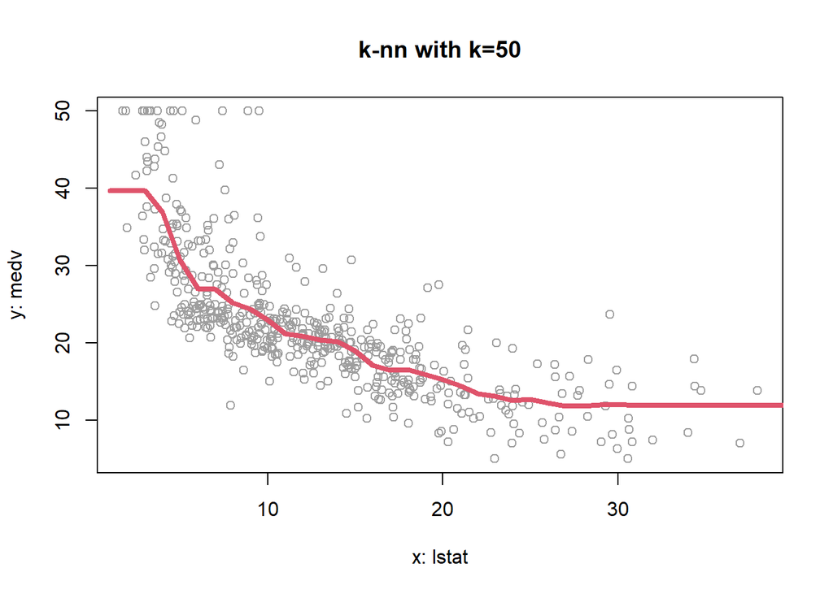

```r
plot(x,y,col=8, xlab="x: lstat", ylab="y: medv")
lines(t,mt,col=2,lwd=4)
title(main=paste0("k-nn with k=",k))
```

## Tuning the model

Repeat the same process using different values of $k$.

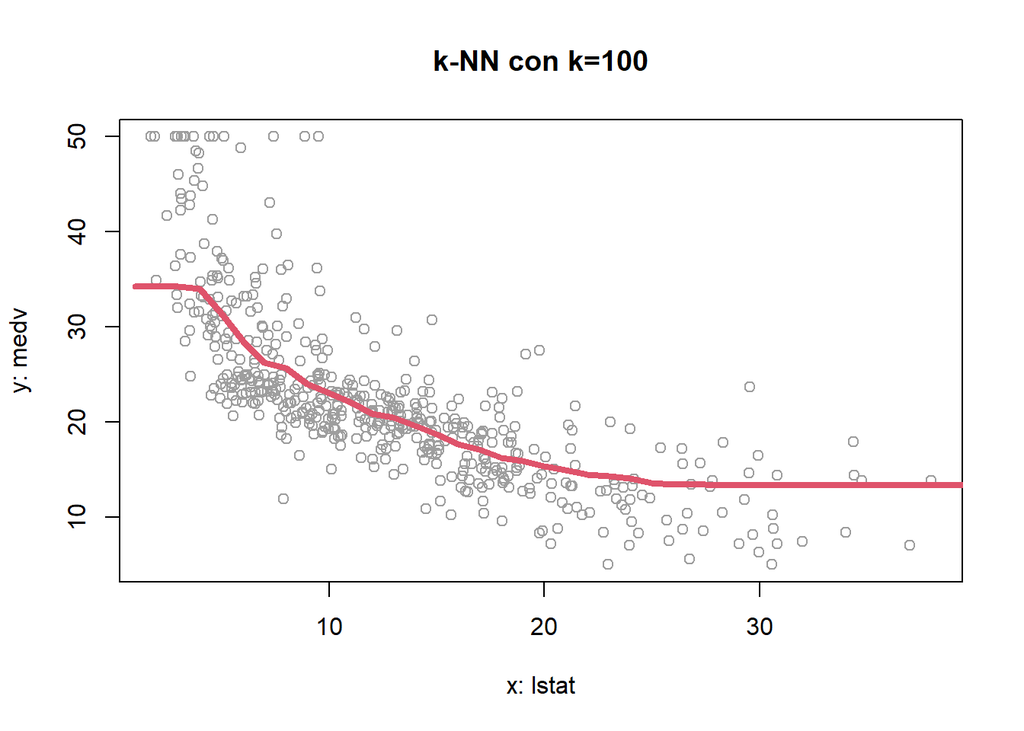

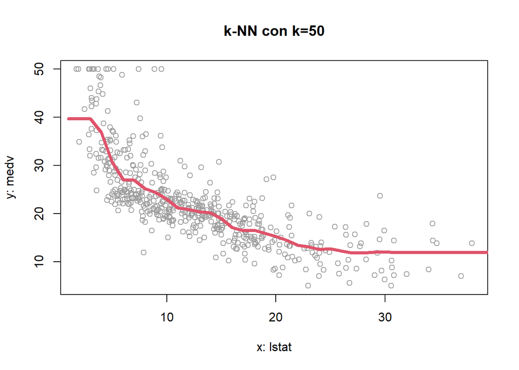

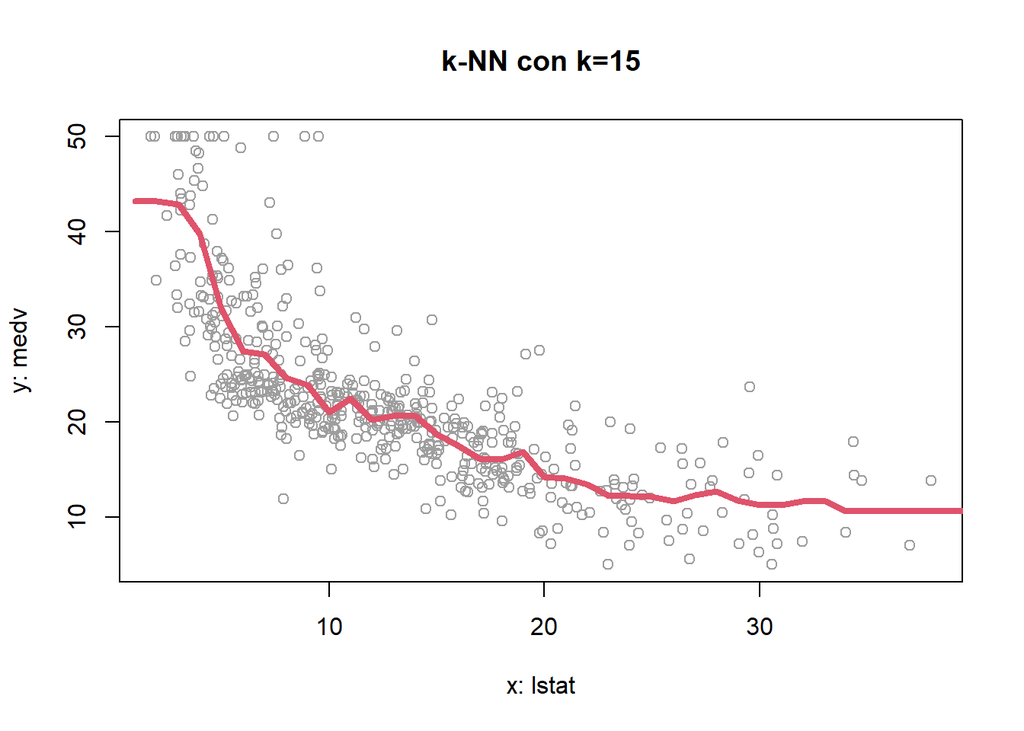

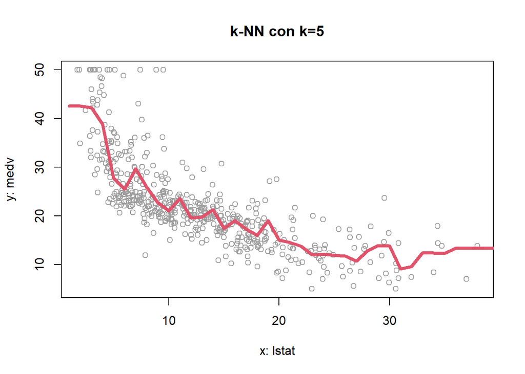

```r
k_values <- c(100, 50, 15, 5)

for (k in k_values) {
    mt <- knn_regr(x, y, t=t, k=k, dist.method = "euclidean")

    plot(x, y, col=8, xlab="x: lstat", ylab="y: medv",
         main=paste0("k-NN con k=", k))
    lines(t, mt, col=2, lwd=4)
}
```

# Model performance

A simple, though not good, idea is to compute the resubstitution (or training) error associated with each model.

When evaluating the performance of a statistical learning model, it is important to distinguish between **training error** (also called **resubstitution error**) and **test error**. In this document, we explain why training error can be misleading and how to properly assess model performance.

## What is Training Error?

Training error is calculated by evaluating the model’s predictions on the same dataset that was used to fit the model. Mathematically, it is computed as:

$$\text{Training Error} = \frac{1}{n} \sum_{i=1}^{n} (y_i -
\hat{m}(x_i))^2$$

where: - $y_i$ are the observed values, - $\hat{m}(x_i)$ are the predicted values from the model, - $n$ is the total number of observations.

### Why is Training Error Misleading?

Since the model is evaluated on the same data it was trained on, the training error is **overly optimistic** and does not provide a reliable measure of how well the model generalizes to new data. This issue is particularly problematic when dealing with flexible models such as **k-nearest neighbors (k-NN)**.

### Example: k-NN and Overfitting

In k-NN regression, the choice of $k$ significantly affects the training error: - When $k$ is **very small**, the model closely follows the training data, leading to **low training error but high test error (overfitting)**. - When $k$ is **too large**, the model smooths out the predictions too much, leading to **higher training and test error (underfitting)**.

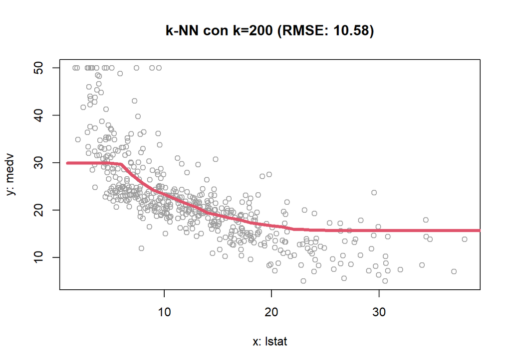

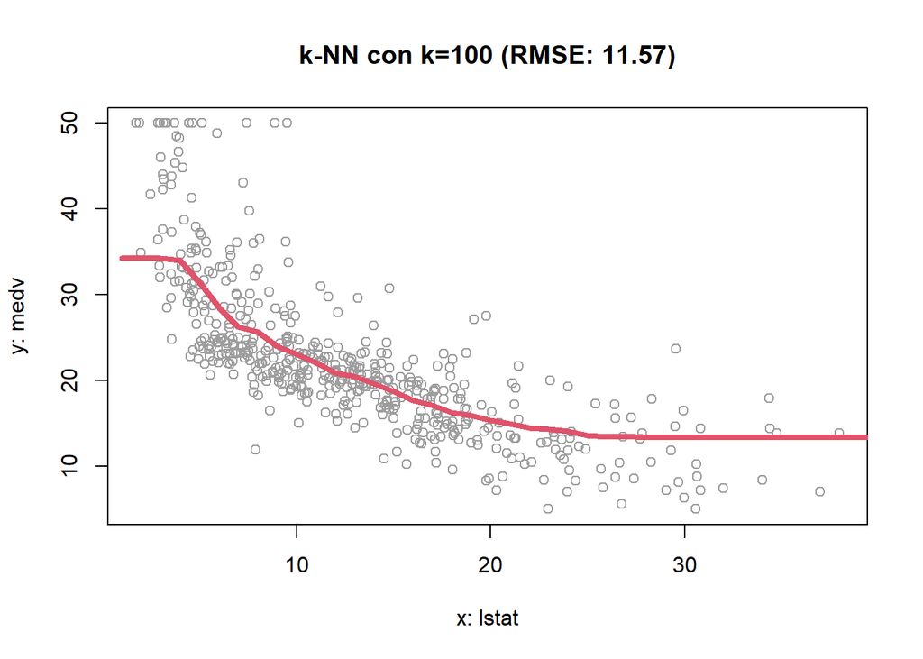

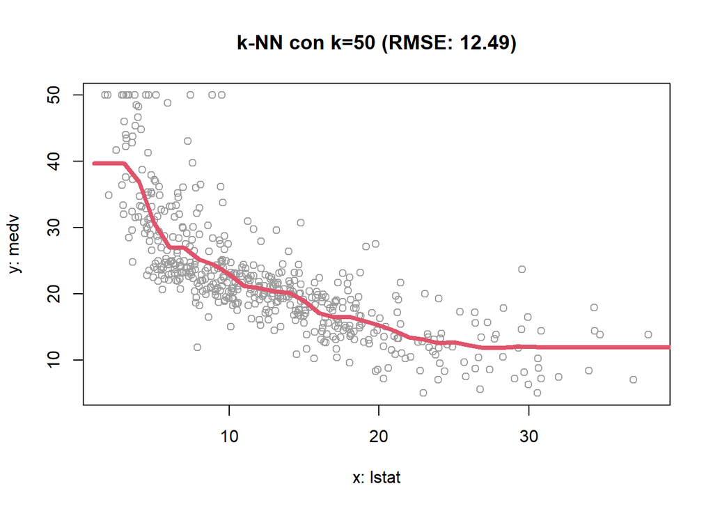

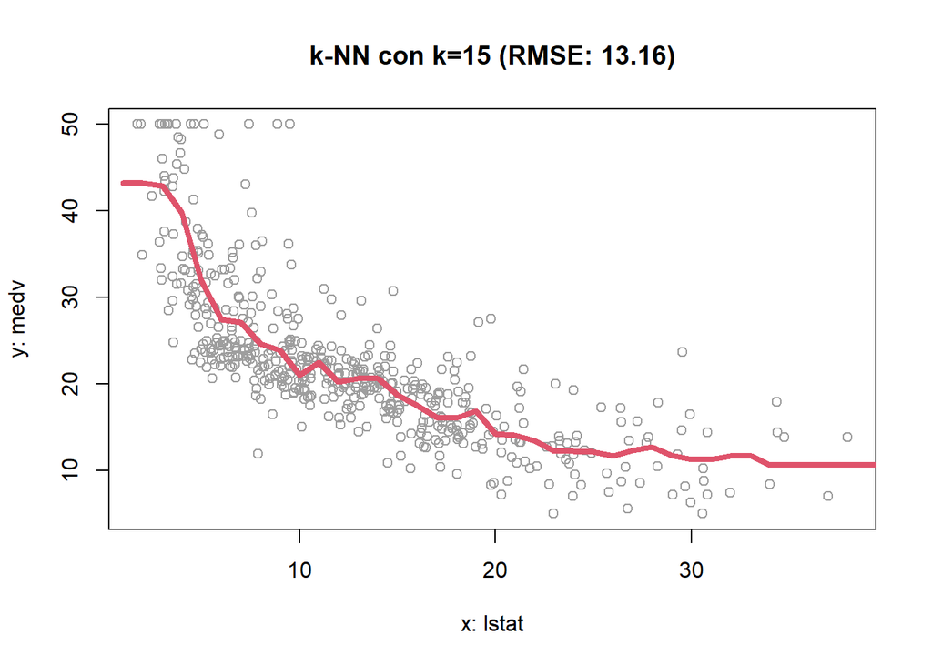

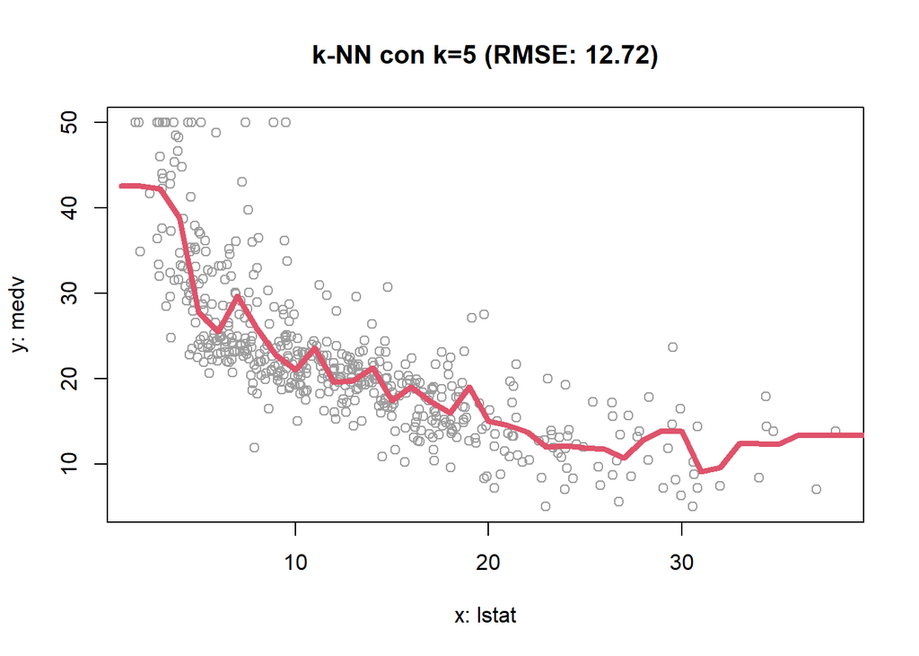

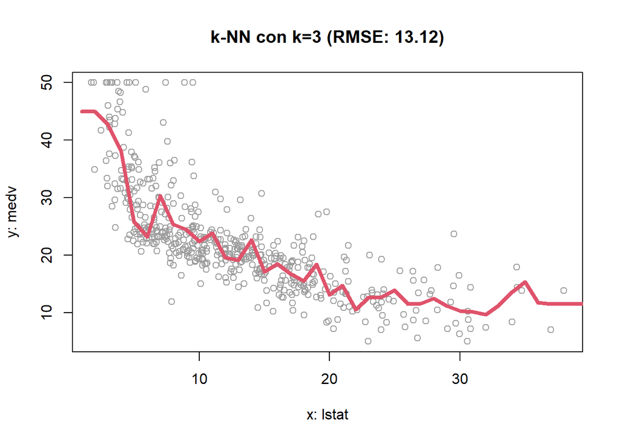

```r
k_values <- c(200, 100, 50, 15, 5, 3)

errors <- data.frame(k = integer(), RMSE = numeric())


for (k in k_values) {
    mt <- knn_regr(x, y, t=t, k=k, dist.method = "euclidean")


    RMSE <- sqrt(mean((y - mt)^2))

    errors <- rbind(errors, data.frame(k = k, RMSE = RMSE))

    plot(x, y, col=8, xlab="x: lstat", ylab="y: medv",
         main=paste0("k-NN con k=", k, " (RMSE: ", round(RMSE, 2), ")"))
    lines(t, mt, col=2, lwd=4)
}
```

```r
print(errors)
```

```
##     k     RMSE
## 1 200 10.57989
## 2 100 11.57428
## 3  50 12.49364
## 4  15 13.15771
## 5   5 12.71861
## 6   3 13.11624
```

## A Better Approach: Using Test Error

To properly evaluate model performance, we must estimate the **test error**, which is computed on a separate dataset that was **not used for training**. This can be done by: 1. **Splitting the data** into a **training set** and a **test set**. 2. **Training the model** on the training set. 3. **Evaluating the model** on the test set and computing the test error:

$$\text{Test Error} = \frac{1}{m} \sum_{j=1}^{m} (y_j^{\text{test}} -
\hat{m}(x_j^{\text{test}}))^2$$

where: - $y_j^{\text{test}}$ are the actual test values, - $\hat{m}(x_j^{\text{test}})$ are the model’s predictions on the test set, - $m$ is the number of test observations.

Using training error alone can give a **false sense of accuracy**. Instead, we should always assess model performance on unseen data (test set) to ensure that our model generalizes well. In the next section, we will implement k-NN regression with a **train-test split** to correctly measure prediction error.

### An (improved) example

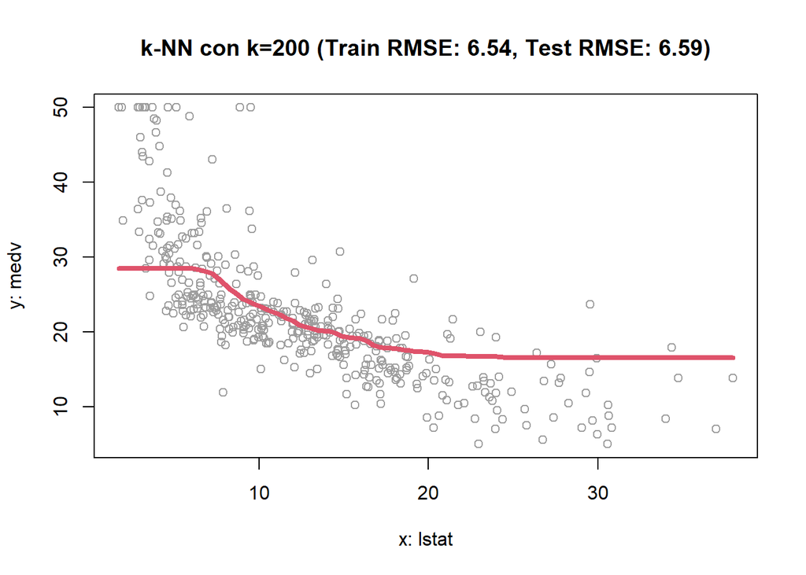

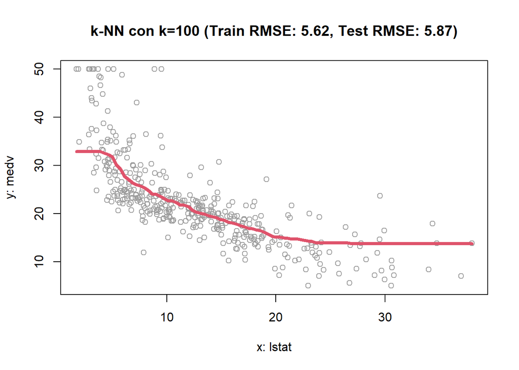

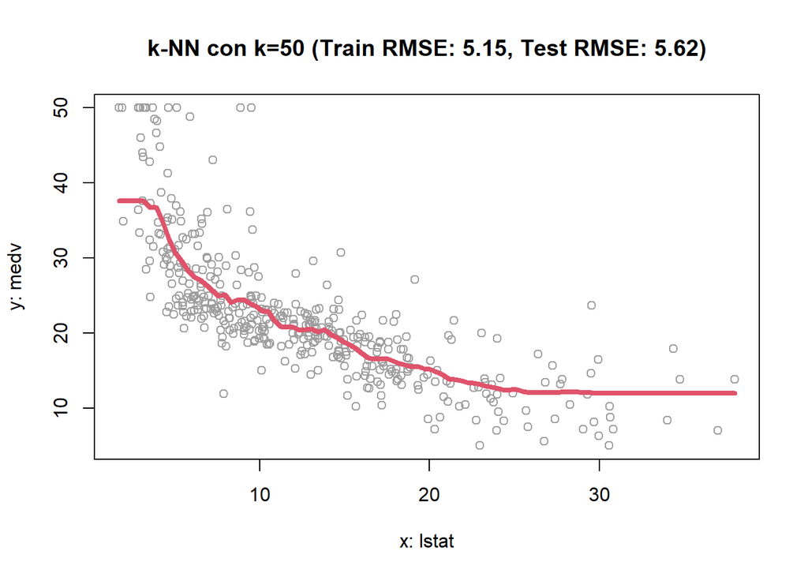

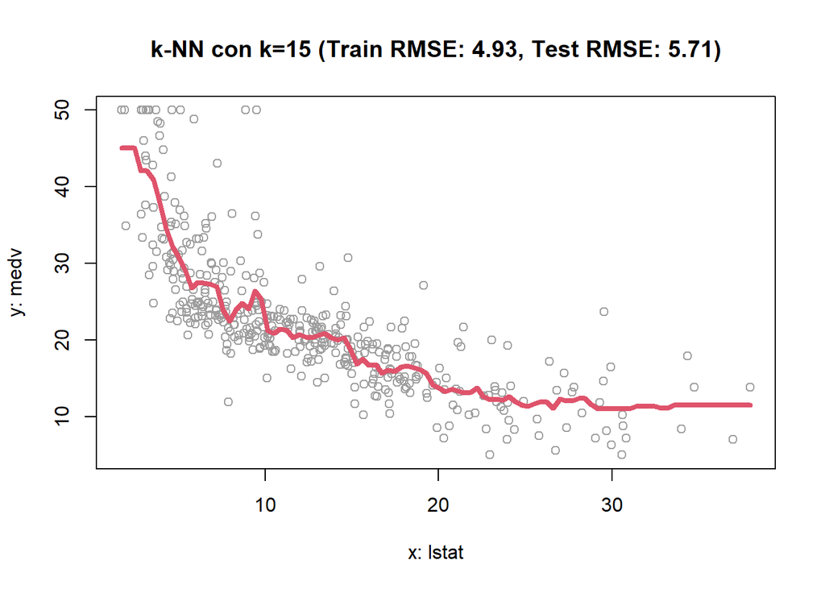

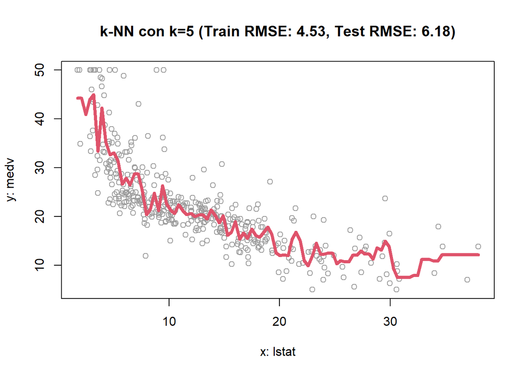

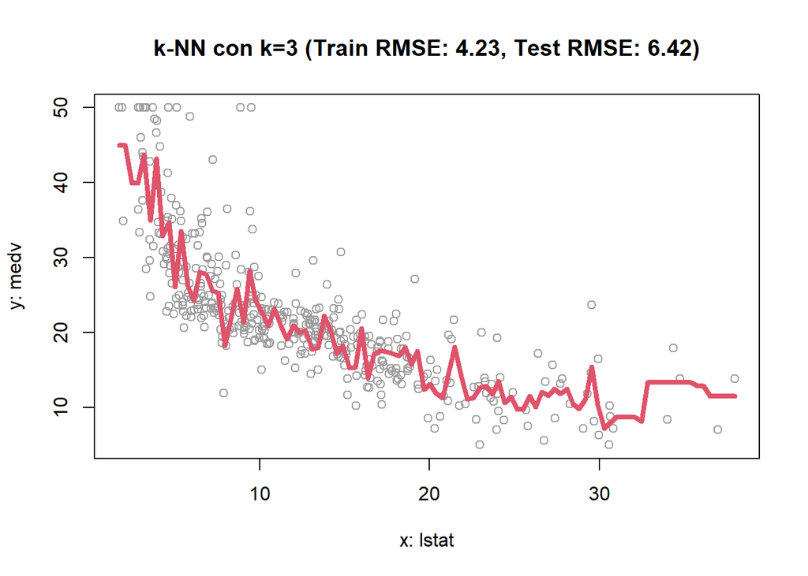

```r
k_values <- c(200, 100, 50, 15, 5, 3)

errors <- data.frame(k = integer(), Training_RMSE = numeric(), Test_RMSE = numeric())

set.seed(123)
n <- length(y)
train_index <- sample(1:n, size = floor(0.8 * n), replace = FALSE)

x_train <- x[train_index]
y_train <- y[train_index]

x_test <- x[-train_index]
y_test <- y[-train_index]


for (k in k_values) {
    mt_train <- knn_regr(x_train, y_train, t=x_train, k=k, dist.method = "euclidean")

    mt_test <- knn_regr(x_train, y_train, t=x_test, k=k, dist.method = "euclidean")

    RMSE_train <- sqrt(mean((y_train - mt_train)^2))
    RMSE_test <- sqrt(mean((y_test - mt_test)^2))

    errors <- rbind(errors, data.frame(k = k, Training_RMSE = RMSE_train, Test_RMSE = RMSE_test))

    plot(x_train, y_train, col=8, xlab="x: lstat", ylab="y: medv",
         main=paste0("k-NN con k=", k, " (Train RMSE: ", round(RMSE_train, 2),
                      ", Test RMSE: ", round(RMSE_test, 2), ")"))

    t_seq <- seq(min(x), max(x), length.out=100)
    mt_seq <- knn_regr(x_train, y_train, t=t_seq, k=k, dist.method = "euclidean")
    lines(t_seq, mt_seq, col=2, lwd=4)
}
```

```r
print(errors)
```

```
##     k Training_RMSE Test_RMSE
## 1 200      6.540422  6.589752
## 2 100      5.624611  5.867107
## 3  50      5.146213  5.624467
## 4  15      4.929732  5.709414
## 5   5      4.530371  6.175764
## 6   3      4.229030  6.422137
```

# Step-by-step Explanation of the knn_regr Function

The function `knn_regr` implements **k-nearest neighbors (k-NN) regression**. This method estimates the conditional expectation $E(Y | X = t)$ by averaging the values of the $k$ closest neighbors of $t$ in the training data. Below, we explain each step of the function in detail.

This function provides a simple implementation of k-NN regression by computing distances, identifying the nearest neighbors, and averaging their response values.

## Function Code

```r
knn_regr <- function(x, y, t=NULL, k=3, dist.method = "euclidean") {
    nx <- length(y)  # Number of observations in the training data

    # If t is not provided, use x as the set of query points
    if (is.null(t)) {
        t <- as.matrix(x)
    } else {
        t <- as.matrix(t)
    }

    nt <- dim(t)[1]  # Number of query points

    # Compute the distance matrix between each t[j] and all x[i]
    Dtx <- as.matrix(dist(rbind(t, as.matrix(x)), method = dist.method))

    # Extract only the distances between test points and training points
    Dtx <- Dtx[1:nt, nt+(1:nx)]

    mt <- numeric(nt)  # Initialize the vector of predictions

    # Compute the k-NN estimate for each query point t[j]
    for (j in 1:nt) {
        d_t_x <- Dtx[j,]  # Distances from t[j] to all training points
        d_t_x_k <- sort(d_t_x, partial=k)[k]  # Distance to the k-th nearest neighbor
        N_t_k <- unname(which(d_t_x <= d_t_x_k))  # Indices of the k nearest neighbors

        mt[j] <- mean(y[N_t_k])  # Compute the mean response of k nearest neighbors
    }

    return(mt)  # Return the vector of estimated values
}
```

## Step-by-Step Explanation

### 1. Function Inputs

The function takes the following inputs: - `x`: The vector of predictor values (training data). - `y`: The corresponding response values. - `t`: A vector of test points where we want to estimate $E(Y | X = t)$. If `t` is not provided, it defaults to `x` (in-sample estimation). - `k`: The number of nearest neighbors to consider. - `dist.method`: The method used to compute distances (default: Euclidean).

### 2. Checking the Input `t`

If `t` is `NULL`, the function assigns `x` to `t`, meaning that predictions will be computed for the training points.

```r
if (is.null(t)){
    t <- as.matrix(x)
} else {
    t <- as.matrix(t)
}
```

### 3. Compute the Distance Matrix

The function calculates pairwise distances between every point in `t` and every point in `x` using the `dist` function.

```r
dist.method <- "euclidean"
Dtx <- as.matrix(dist(rbind(t, as.matrix(x)), method = dist.method))
```

After computing the distance matrix, we extract only the distances between test points and training points:

```r
Dtx <- Dtx[1:nt, nt+(1:nx)]
```

### 4. Find the k Nearest Neighbors

For each test point $t[j]$: - Extract the distances to all training points. - Identify the **k-th smallest** distance. - Select the indices of the **k closest** training points.

```r
d_t_x <- Dtx[j,]  # Distances from t[j] to all training points
d_t_x_k <- sort(d_t_x, partial=k)[k]  # Distance to the k-th nearest neighbor
N_t_k <- unname(which(d_t_x <= d_t_x_k))  # Indices of the k nearest neighbors
```

### 5. Compute the k-NN Estimate

Once the nearest neighbors are identified, their corresponding `y` values are averaged to compute the estimate:

```r
mt[j] <- mean(y[N_t_k])  # Compute the mean response of k nearest neighbors
```

### 6. Return the Estimated Values

Finally, the function returns the vector `mt` containing the estimated values for all test points.

```r
return(mt)
```